# Data 607 - Final Project

Joby John / Peter Kowalchuk

11/28/2018

# Introduction

Every two years our nation goes thru the process of electing out government officials. It seems every year the bipartisan rhetoric gets stronger and strong. Many claims are made on what happens to the economy when either party is in control, of the President’s office, the Senate or the House. Coming right out of the mid-terms, looking at what next year brings economically is certainly of interest to all.

Gathering data from the Federal Reserve’s FRED service ( https://fred.stlouisfed.org ) and from scrapping results from elections from the web (such as https://transition.fec.gov/pubrec/electionresults.shtm), we can build a model of what next year has in store.

We would start out by selecting economic indicators from the FRED site. Selecting interesting indicators will be done using Wickham’s workflow. Data will be imported, made tidy, possible transformations applied and then thru visualization the most “interesting” indicators will be selected.

Electoral data will include the number of senate and house seats in congress the year after an election. Using this data together with our economic indicators, models will be built to predict a certain economic indicator. Several models can be used, presenting results from each in graphical form. We can also classify monthly economic data with a good, medium and poor economy tag. Once we do this we can train a classifier to tell us what the economic outlook might be given an input of congress seats.

There seems to be the notion that Python is a better language for machine learning and running classifiers. As a stretch got for this project, to experiment with something not covered in class, we can try running python code in RStudio using the reticulate library. If this is possible, training a classifier using the popular sci-kitlearn package in Python and comparing them with results in r, could give us a clue into which is better at machine learning.

# Workflow

We will use Hadley Wickman’s Tidy Workflow as show below.

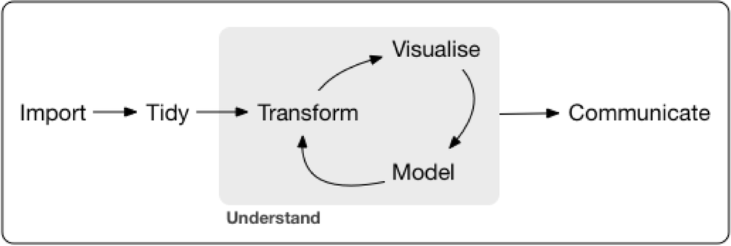

**Loading required libraries**

```r
library("rvest")
library(tidyr)
require(mongolite)
library(dplyr)
```

```r
library(ggplot2)

library(FredR)
library(pipeR)
library(kableExtra)

library(reticulate)
library(reshape2)
```

# Import Data

## Economic Indicators Dataset

The Federal Reserve’s database has a selection of economic indicators. For this analysis we will look at GDP (Gross Domestic Product) indicators as a proxy for the health of the economy. To select an indicator we can first explore GDP indicators available.

```r
api.key = "4844eb6986119824760163e60bddd945"
fred<-FredR(api.key)

gdp.series <- fred$series.search("GDP")
gdp.series %>% kable() %>% kable_styling() %>% scroll_box(height = "400px")
```

| id | realtime_start | realtime_end | title | observation_start | observation_end | frequency | frequency_short | units | units_short | seasonal_adjustment | seasonal_adjustment_short | last_updated | popularity | group_popularity | notes |
| --- | --- | --- | --- | --- | --- | --- | --- | --- | --- | --- | --- | --- | --- | --- | --- |
| GDPC1 | 2018-12-09 | 2018-12-09 | Real Gross Domestic Product | 1947-01-01 | 2018-07-01 | Quarterly | Q | Billions of Chained 2012 Dollars | Bil. of Chn. 2012 $ | Seasonally Adjusted Annual Rate | SAAR | 2018-11-28 07:51:02-06 | 94 | 98 | BEA Account Code: A191RX Real gross domestic product is the inflation adjusted value of the goods and services produced by labor and property located in the United States.For more information see the … |
| GDP | 2018-12-09 | 2018-12-09 | Gross Domestic Product | 1947-01-01 | 2018-07-01 | Quarterly | Q | Billions of Dollars | Bil. of $ | Seasonally Adjusted Annual Rate | SAAR | 2018-11-28 07:51:02-06 | 92 | 93 | BEA Account Code: A191RC Gross domestic product (GDP), the featured measure of U.S. output, is the market value of the goods and services produced by labor and property located in the United States.Fo… |
| A191RL1Q225SBEA | 2018-12-09 | 2018-12-09 | Real Gross Domestic Product | 1947-04-01 | 2018-07-01 | Quarterly | Q | Percent Change from Preceding Period | % Chg. from Preceding Period | Seasonally Adjusted Annual Rate | SAAR | 2018-10-26 07:51:03-05 | 89 | 98 | BEA Account Code: A191RL Gross domestic product (GDP) is the value of the goods and services produced by the nation’s economy less the value of the goods and services used up in production. GDP is als… |
| PAYEMS | 2018-12-09 | 2018-12-09 | All Employees: Total Nonfarm Payrolls | 1939-01-01 | 2018-11-01 | Monthly | M | Thousands of Persons | Thous. of Persons | Seasonally Adjusted | SA | 2018-12-07 08:11:02-06 | 85 | 85 | All Employees: Total Nonfarm, commonly known as Total Nonfarm Payroll, is a measure of the number of U.S. workers in the economy that excludes proprietors, private household employees, unpaid voluntee… |
| GFDEGDQ188S | 2018-12-09 | 2018-12-09 | Federal Debt: Total Public Debt as Percent of Gross Domestic Product | 1966-01-01 | 2018-07-01 | Quarterly | Q | Percent of GDP | % of GDP | Seasonally Adjusted | SA | 2018-11-29 14:51:02-06 | 84 | 84 | Federal Debt: Total Public Debt as Percent of Gross Domestic Product (GFDEGDQ188S) was first constructed by the Federal Reserve Bank of St. Louis in October 2012. It is calculated using Federal Govern… |
| M2V | 2018-12-09 | 2018-12-09 | Velocity of M2 Money Stock | 1959-01-01 | 2018-07-01 | Quarterly | Q | Ratio | Ratio | Seasonally Adjusted | SA | 2018-10-26 15:51:01-05 | 84 | 84 | Calculated as the ratio of quarterly nominal GDP (https://fred.stlouisfed.org/series/GDP) to the quarterly average of M2 money stock (https://fred.stlouisfed.org/series/M2SL). The velocity of money is… |
| A939RX0Q048SBEA | 2018-12-09 | 2018-12-09 | Real gross domestic product per capita | 1947-01-01 | 2018-07-01 | Quarterly | Q | Chained 2012 Dollars | Chn. 2012 $ | Seasonally Adjusted Annual Rate | SAAR | 2018-11-28 07:51:02-06 | 79 | 79 | BEA Account Code: A939RX For more information about this series, please see http://www.bea.gov/national/. |
| GDPDEF | 2018-12-09 | 2018-12-09 | Gross Domestic Product: Implicit Price Deflator | 1947-01-01 | 2018-07-01 | Quarterly | Q | Index 2012=100 | Index 2012=100 | Seasonally Adjusted | SA | 2018-11-28 07:51:02-06 | 79 | 79 | BEA Account Code: A191RD The number of decimal places reported varies over time. A Guide to the National Income and Product Accounts of the United States (NIPA) - (http://www.bea.gov/national/pdf/nipa… |
| HDTGPDUSQ163N | 2018-12-09 | 2018-12-09 | Household Debt to GDP for United States | 2005-01-01 | 2016-10-01 | Quarterly | Q | Ratio | Ratio | Not Seasonally Adjusted | NSA | 2017-04-27 10:01:01-05 | 78 | 78 | The data for household debt comprise debt incurred by resident households of the economy only. This FSI measures the overall level of household indebtedness (commonly related to consumer loans and mor… |
| GDPPOT | 2018-12-09 | 2018-12-09 | Real Potential Gross Domestic Product | 1949-01-01 | 2028-10-01 | Quarterly | Q | Billions of Chained 2009 Dollars | Bil. of Chn. 2009 $ | Not Seasonally Adjusted | NSA | 2018-08-27 14:01:02-05 | 77 | 77 | Real potential GDP is the CBO’s estimate of the output the economy would produce with a high rate of use of its capital and labor resources. The data is adjusted to remove the effects of inflation. |
| NROU | 2018-12-09 | 2018-12-09 | Natural Rate of Unemployment (Long-Term) | 1949-01-01 | 2028-10-01 | Quarterly | Q | Percent | % | Not Seasonally Adjusted | NSA | 2018-08-27 14:01:02-05 | 76 | 76 | The natural rate of unemployment (NAIRU) is the rate of unemployment arising from all sources except fluctuations in aggregate demand. Estimates of potential GDP are based on the long-term natural rat… |
| DDDM01USA156NWDB | 2018-12-09 | 2018-12-09 | Stock Market Capitalization to GDP for United States | 1975-01-01 | 2017-01-01 | Annual | A | Percent | % | Not Seasonally Adjusted | NSA | 2018-09-21 11:21:02-05 | 75 | 75 | Total value of all listed shares in a stock market as a percentage of GDP. Value of listed shares to GDP, calculated using the following deflation method: {(0.5)*[Ft/P_et + Ft-1/P_et-1]}/[GDPt/P_at] w… |
| FYFSGDA188S | 2018-12-09 | 2018-12-09 | Federal Surplus or Deficit [-] as Percent of Gross Domestic Product | 1929-01-01 | 2017-01-01 | Annual | A | Percent of GDP | % of GDP | Not Seasonally Adjusted | NSA | 2018-10-16 11:11:01-05 | 75 | 75 | Federal Surplus or Deficit [-] as Percent of Gross Domestic Product (FYFSGDA188S) was first constructed by the Federal Reserve Bank of St. Louis in October 2012. It is calculated using Federal Surplus… |
| CP | 2018-12-09 | 2018-12-09 | Corporate Profits After Tax (without IVA and CCAdj) | 1947-01-01 | 2018-07-01 | Quarterly | Q | Billions of Dollars | Bil. of $ | Seasonally Adjusted Annual Rate | SAAR | 2018-11-28 07:51:03-06 | 74 | 74 | BEA Account Code: A055RC |
| GDPCA | 2018-12-09 | 2018-12-09 | Real Gross Domestic Product | 1929-01-01 | 2017-01-01 | Annual | A | Billions of Chained 2012 Dollars | Bil. of Chn. 2012 $ | Not Seasonally Adjusted | NSA | 2018-07-27 10:32:49-05 | 74 | 98 | BEA Account Code: A191RX A Guide to the National Income and Product Accounts of the United States (NIPA) - (http://www.bea.gov/national/pdf/nipaguid.pdf) |
| GPDI | 2018-12-09 | 2018-12-09 | Gross Private Domestic Investment | 1947-01-01 | 2018-07-01 | Quarterly | Q | Billions of Dollars | Bil. of $ | Seasonally Adjusted Annual Rate | SAAR | 2018-11-28 07:51:03-06 | 74 | 75 | BEA Account Code: A006RC A Guide to the National Income and Product Accounts of the United States (NIPA) - (http://www.bea.gov/national/pdf/nipaguid.pdf) |
| GDPA | 2018-12-09 | 2018-12-09 | Gross Domestic Product | 1929-01-01 | 2017-01-01 | Annual | A | Billions of Dollars | Bil. of $ | Not Seasonally Adjusted | NSA | 2018-07-27 10:32:48-05 | 74 | 93 | BEA Account Code: A191RC |
| M1V | 2018-12-09 | 2018-12-09 | Velocity of M1 Money Stock | 1959-01-01 | 2018-07-01 | Quarterly | Q | Ratio | Ratio | Seasonally Adjusted | SA | 2018-10-26 15:51:02-05 | 73 | 73 | Calculated as the ratio of quarterly nominal GDP (https://fred.stlouisfed.org/series/GDP) to the quarterly average of M1 money stock (https://fred.stlouisfed.org/series/M1SL). The velocity of money is… |
| W006RC1Q027SBEA | 2018-12-09 | 2018-12-09 | Federal government current tax receipts | 1947-01-01 | 2018-07-01 | Quarterly | Q | Billions of Dollars | Bil. of $ | Seasonally Adjusted Annual Rate | SAAR | 2018-11-28 07:51:03-06 | 73 | 73 | BEA Account Code: W006RC For more information about this series, please see http://www.bea.gov/national/. |
| A191RO1Q156NBEA | 2018-12-09 | 2018-12-09 | Real Gross Domestic Product | 1948-01-01 | 2018-07-01 | Quarterly | Q | Percent Change from Quarter One Year Ago | % Chg. from Qtr. 1 Yr. Ago | Seasonally Adjusted | SA | 2018-10-26 07:54:03-05 | 71 | 98 | BEA Account Code: A191RO For more information about this series, please see http://www.bea.gov/national/. |
| A191RL1A225NBEA | 2018-12-09 | 2018-12-09 | Real Gross Domestic Product | 1930-01-01 | 2017-01-01 | Annual | A | Percent Change from Preceding Period | % Chg. from Preceding Period | Not Seasonally Adjusted | NSA | 2018-07-27 10:21:01-05 | 71 | 98 | BEA Account Code: A191RL For more information about this series, please see http://www.bea.gov/national/. |
| JHDUSRGDPBR | 2018-12-09 | 2018-12-09 | Dates of U.S. recessions as inferred by GDP-based recession indicator | 1967-10-01 | 2018-04-01 | Quarterly | Q | +1 or 0 | +1 or 0 | Not Seasonally Adjusted | NSA | 2018-10-26 15:41:01-05 | 71 | 71 | The series assigns dates to U.S. recessions based on a mathematical model of the way that recessions differ from expansions. Whereas the NBER business cycle dates are based on a subjective assessment … |
| PCEC | 2018-12-09 | 2018-12-09 | Personal Consumption Expenditures | 1947-01-01 | 2018-07-01 | Quarterly | Q | Billions of Dollars | Bil. of $ | Seasonally Adjusted Annual Rate | SAAR | 2018-11-28 07:51:03-06 | 70 | 84 | BEA Account Code: DPCERC A Guide to the National Income and Product Accounts of the United States (NIPA) - (http://www.bea.gov/national/pdf/nipaguid.pdf) |
| PCECC96 | 2018-12-09 | 2018-12-09 | Real Personal Consumption Expenditures | 1947-01-01 | 2018-07-01 | Quarterly | Q | Billions of Chained 2012 Dollars | Bil. of Chn. 2012 $ | Seasonally Adjusted Annual Rate | SAAR | 2018-11-28 07:51:03-06 | 70 | 82 | BEA Account Code: DPCERX A Guide to the National Income and Product Accounts of the United States (NIPA) - (http://www.bea.gov/national/pdf/nipaguid.pdf) |
| NETEXP | 2018-12-09 | 2018-12-09 | Net Exports of Goods and Services | 1947-01-01 | 2018-07-01 | Quarterly | Q | Billions of Dollars | Bil. of $ | Seasonally Adjusted Annual Rate | SAAR | 2018-11-28 07:51:03-06 | 70 | 71 | BEA Account Code: A019RC A Guide to the National Income and Product Accounts of the United States (NIPA) - (http://www.bea.gov/national/pdf/nipaguid.pdf) |
| A191RP1Q027SBEA | 2018-12-09 | 2018-12-09 | Gross Domestic Product | 1947-04-01 | 2018-07-01 | Quarterly | Q | Percent Change from Preceding Period | % Chg. from Preceding Period | Seasonally Adjusted Annual Rate | SAAR | 2018-11-28 07:51:03-06 | 69 | 93 | BEA Account Code: A191RP For more information about this series, please see http://www.bea.gov/national/. |
| GNP | 2018-12-09 | 2018-12-09 | Gross National Product | 1947-01-01 | 2018-07-01 | Quarterly | Q | Billions of Dollars | Bil. of $ | Seasonally Adjusted Annual Rate | SAAR | 2018-11-28 07:51:03-06 | 69 | 71 | BEA Account Code: A001RC A Guide to the National Income and Product Accounts of the United States (NIPA) - (http://www.bea.gov/national/pdf/nipaguid.pdf) |
| MKTGDPCNA646NWDB | 2018-12-09 | 2018-12-09 | Gross Domestic Product for China | 1960-01-01 | 2017-01-01 | Annual | A | Current U.S. Dollars | Current $ | Not Seasonally Adjusted | NSA | 2018-09-27 13:32:21-05 | 68 | 68 | GDP at purchaser’s prices is the sum of gross value added by all resident producers in the economy plus any product taxes and minus any subsidies not included in the value of the products. It is calcu… |
| GDPNOW | 2018-12-09 | 2018-12-09 | GDPNow | 2011-07-01 | 2018-10-01 | Quarterly | Q | Percent Change at Annual Rate | % Chg. at Annual Rate | Seasonally Adjusted Annual Rate | SAAR | 2018-12-07 16:41:02-06 | 68 | 68 | GDPNow is a nowcasting model for gross domestic product (GDP) growth that synthesizes the bridge equation approach relating GDP subcomponents to monthly source data with factor model and Bayesian vect… |
| STLENI | 2018-12-09 | 2018-12-09 | St. Louis Fed Economic News Index: Real GDP Nowcast | 2013-04-01 | 2018-10-01 | Quarterly | Q | Percent Change at Annual Rate | % Chg. at Annual Rate | Seasonally Adjusted Annual Rate | SAAR | 2018-12-07 10:01:08-06 | 67 | 67 | St. Louis Fed’s Economic News Index (ENI) uses economic content from key monthly economic data releases to forecast the growth of real GDP during that quarter. In general, the most-current observation… |

[output cut: 70 more lines]

From this selection we decide to use two indicators: Gross Domestic Product per Capita and Real Personal Consumption Expenditures.

```r
#Gross domestic product
gdp <- fred$series.observations(series_id = 'A939RX0Q048SBEA')
head(gdp,n=100) %>% kable() %>% kable_styling() %>% scroll_box(height = "400px")
```

| realtime_start | realtime_end | date | value |
| --- | --- | --- | --- |
| 2018-12-09 | 2018-12-09 | 1947-01-01 | 14203.0 |
| 2018-12-09 | 2018-12-09 | 1947-04-01 | 14101.0 |
| 2018-12-09 | 2018-12-09 | 1947-07-01 | 14008.0 |
| 2018-12-09 | 2018-12-09 | 1947-10-01 | 14161.0 |
| 2018-12-09 | 2018-12-09 | 1948-01-01 | 14316.0 |
| 2018-12-09 | 2018-12-09 | 1948-04-01 | 14495.0 |
| 2018-12-09 | 2018-12-09 | 1948-07-01 | 14515.0 |
| 2018-12-09 | 2018-12-09 | 1948-10-01 | 14464.0 |
| 2018-12-09 | 2018-12-09 | 1949-01-01 | 14202.0 |
| 2018-12-09 | 2018-12-09 | 1949-04-01 | 14098.0 |
| 2018-12-09 | 2018-12-09 | 1949-07-01 | 14182.0 |
| 2018-12-09 | 2018-12-09 | 1949-10-01 | 13999.0 |
| 2018-12-09 | 2018-12-09 | 1950-01-01 | 14490.0 |
| 2018-12-09 | 2018-12-09 | 1950-04-01 | 14879.0 |
| 2018-12-09 | 2018-12-09 | 1950-07-01 | 15388.0 |
| 2018-12-09 | 2018-12-09 | 1950-10-01 | 15612.0 |
| 2018-12-09 | 2018-12-09 | 1951-01-01 | 15759.0 |
| 2018-12-09 | 2018-12-09 | 1951-04-01 | 15968.0 |
| 2018-12-09 | 2018-12-09 | 1951-07-01 | 16223.0 |
| 2018-12-09 | 2018-12-09 | 1951-10-01 | 16181.0 |
| 2018-12-09 | 2018-12-09 | 1952-01-01 | 16288.0 |
| 2018-12-09 | 2018-12-09 | 1952-04-01 | 16259.0 |
| 2018-12-09 | 2018-12-09 | 1952-07-01 | 16306.0 |
| 2018-12-09 | 2018-12-09 | 1952-10-01 | 16765.0 |
| 2018-12-09 | 2018-12-09 | 1953-01-01 | 17013.0 |
| 2018-12-09 | 2018-12-09 | 1953-04-01 | 17082.0 |
| 2018-12-09 | 2018-12-09 | 1953-07-01 | 16908.0 |
| 2018-12-09 | 2018-12-09 | 1953-10-01 | 16574.0 |
| 2018-12-09 | 2018-12-09 | 1954-01-01 | 16425.0 |
| 2018-12-09 | 2018-12-09 | 1954-04-01 | 16376.0 |

[output cut: 70 more lines]

```r
#Real Personal Consumption Expenditures
rpce <- fred$series.observations(series_id = 'DPCERL1Q225SBEA')
head(rpce,n=100) %>% kable() %>% kable_styling() %>% scroll_box(height = "400px")
```

| realtime_start | realtime_end | date | value |
| --- | --- | --- | --- |
| 2018-12-09 | 2018-12-09 | 1947-04-01 | 6.8 |
| 2018-12-09 | 2018-12-09 | 1947-07-01 | 1.3 |
| 2018-12-09 | 2018-12-09 | 1947-10-01 | 0.1 |
| 2018-12-09 | 2018-12-09 | 1948-01-01 | 2 |
| 2018-12-09 | 2018-12-09 | 1948-04-01 | 4.7 |
| 2018-12-09 | 2018-12-09 | 1948-07-01 | 0.6 |
| 2018-12-09 | 2018-12-09 | 1948-10-01 | 3.2 |
| 2018-12-09 | 2018-12-09 | 1949-01-01 | 0.7 |
| 2018-12-09 | 2018-12-09 | 1949-04-01 | 6.3 |
| 2018-12-09 | 2018-12-09 | 1949-07-01 | 0.9 |
| 2018-12-09 | 2018-12-09 | 1949-10-01 | 6 |
| 2018-12-09 | 2018-12-09 | 1950-01-01 | 6.8 |
| 2018-12-09 | 2018-12-09 | 1950-04-01 | 6.8 |
| 2018-12-09 | 2018-12-09 | 1950-07-01 | 22.2 |
| 2018-12-09 | 2018-12-09 | 1950-10-01 | -11.5 |
| 2018-12-09 | 2018-12-09 | 1951-01-01 | 10 |
| 2018-12-09 | 2018-12-09 | 1951-04-01 | -10.8 |
| 2018-12-09 | 2018-12-09 | 1951-07-01 | 4.7 |
| 2018-12-09 | 2018-12-09 | 1951-10-01 | 2.4 |
| 2018-12-09 | 2018-12-09 | 1952-01-01 | 0.9 |
| 2018-12-09 | 2018-12-09 | 1952-04-01 | 8.0 |
| 2018-12-09 | 2018-12-09 | 1952-07-01 | 1.9 |
| 2018-12-09 | 2018-12-09 | 1952-10-01 | 14.9 |
| 2018-12-09 | 2018-12-09 | 1953-01-01 | 4.8 |
| 2018-12-09 | 2018-12-09 | 1953-04-01 | 2.4 |
| 2018-12-09 | 2018-12-09 | 1953-07-01 | -1.0 |
| 2018-12-09 | 2018-12-09 | 1953-10-01 | -2.7 |
| 2018-12-09 | 2018-12-09 | 1954-01-01 | 1.5 |
| 2018-12-09 | 2018-12-09 | 1954-04-01 | 5.3 |
| 2018-12-09 | 2018-12-09 | 1954-07-01 | 5.5 |

[output cut: 70 more lines]

## Electoral Dataset

For this analysis we will need data showing the number of congress and senate seats occupied by both parties. This data was scrapped from The University of Wisconsin’s web page.

```r
url <- "https://web.education.wisc.edu/nwhillman/index.php/2017/02/01/party-control-in-congress-and-state-legislatures/"
congress_by_party <- url %>%
  read_html() %>%
  html_table()
# this is wide format .
congress_by_party <- congress_by_party[[1]]
head(congress_by_party,n=100) %>% kable() %>% kable_styling() %>% scroll_box(height = "400px")
```

| X1 | X2 | X3 | X4 | X5 | X6 | X7 | X8 | X9 | X10 |
| --- | --- | --- | --- | --- | --- | --- | --- | --- | --- |
| NA | Senate | Senate | Senate | House | House | House | State Legislatures | State Legislatures | State Legislatures |
| NA | Dem | Rep | Oth | Dem | Rep | Oth | Dem | Rep | Split+NE |
| 1978 | 58 | 41 | 1 | 277 | 158 | 0 | 31 | 11 | 8 |
| 1980 | 46 | 53 | 1 | 242 | 192 | 1 | 28 | 15 | 7 |
| 1982 | 46 | 54 | 0 | 269 | 166 | 0 | 34 | 10 | 6 |
| 1984 | 47 | 53 | 0 | 253 | 182 | 0 | 28 | 10 | 12 |
| 1986 | 55 | 45 | 0 | 258 | 177 | 0 | 27 | 9 | 14 |
| 1988 | 55 | 45 | 0 | 260 | 175 | 0 | 29 | 8 | 13 |
| 1990 | 56 | 44 | 0 | 267 | 167 | 1 | 29 | 6 | 15 |
| 1992 | 57 | 43 | 0 | 258 | 176 | 1 | 26 | 7 | 17 |
| 1994 | 48 | 52 | 0 | 204 | 230 | 1 | 22 | 15 | 13 |
| 1996 | 45 | 55 | 0 | 207 | 226 | 2 | 20 | 17 | 13 |
| 1998 | 45 | 55 | 0 | 211 | 223 | 1 | 20 | 17 | 13 |
| 2000 | 50 | 50 | 0 | 212 | 221 | 2 | 16 | 18 | 16 |
| 2002 | 48 | 51 | 1 | 205 | 229 | 1 | 16 | 21 | 13 |
| 2004 | 44 | 55 | 1 | 202 | 231 | 2 | 19 | 20 | 11 |
| 2006 | 49 | 49 | 2 | 233 | 198 | 4 | 23 | 16 | 11 |
| 2008 | 57 | 41 | 2 | 256 | 178 | 1 | 27 | 14 | 9 |
| 2010 | 51 | 47 | 2 | 193 | 242 | 0 | 27 | 14 | 9 |
| 2012 | 54 | 45 | 1 | 201 | 234 | 0 | 15 | 27 | 8 |
| 2014 | 44 | 54 | 2 | 188 | 246 | 1 | 19 | 26 | 5 |
| 2016 | 46 | 52 | 2 | 194 | 241 | 0 | 14 | 32 | 4 |

# Tidy & Transform

## Economic Indicators Dataset

Since our analysis will be annual based, as senate and congress seats change biannually, the economic data gathered from the Federal Reserve site needs to be scaled up from quarterly to annually.

```r
#Scale up data from quarterly to annual
gdp$date<-substring(gdp$date,1,4)
gdp$date<-as.numeric(gdp$date)
gdp$value<-as.numeric(gdp$value)
gdp$value<-gdp$value/4
gdp<-gdp %>% group_by(date) %>% summarise(value=sum(value))
gdp <- gdp %>% mutate(Diff = (value - lag(value))/lag(value)) # we add a column for the GDP difference between each year

rpce$date<-substring(rpce$date,1,4)
rpce$date<-as.numeric(rpce$date)
rpce$value<-as.numeric(rpce$value)
rpce$value<-rpce$value/4
rpce<-rpce %>% group_by(date) %>% summarise(value=sum(value))
```

### Final Economic Indicators Dataset

```r
gdp %>% kable() %>% kable_styling() %>% scroll_box(height = "400px")
```

| date | value | Diff |
| --- | --- | --- |
| 1947 | 14118.25 | NA |
| 1948 | 14447.50 | 0.0233209 |
| 1949 | 14120.25 | -0.0226510 |
| 1950 | 15092.25 | 0.0688373 |
| 1951 | 16032.75 | 0.0623168 |
| 1952 | 16404.50 | 0.0231869 |
| 1953 | 16894.25 | 0.0298546 |
| 1954 | 16503.00 | -0.0231588 |
| 1955 | 17371.25 | 0.0526116 |
| 1956 | 17431.75 | 0.0034828 |
| 1957 | 17481.75 | 0.0028683 |
| 1958 | 17065.25 | -0.0238248 |
| 1959 | 17942.50 | 0.0514056 |
| 1960 | 18035.75 | 0.0051972 |
| 1961 | 18195.50 | 0.0088574 |
| 1962 | 19016.75 | 0.0451348 |
| 1963 | 19560.50 | 0.0285932 |
| 1964 | 20404.50 | 0.0431482 |
| 1965 | 21459.00 | 0.0516798 |
| 1966 | 22613.50 | 0.0538003 |
| 1967 | 22982.25 | 0.0163066 |
| 1968 | 23872.00 | 0.0387147 |
| 1969 | 24376.75 | 0.0211440 |
| 1970 | 24142.50 | -0.0096096 |
| 1971 | 24624.25 | 0.0199544 |
| 1972 | 25642.75 | 0.0413617 |
| 1973 | 26834.25 | 0.0464654 |
| 1974 | 26445.50 | -0.0144871 |
| 1975 | 26134.75 | -0.0117506 |
| 1976 | 27277.50 | 0.0437253 |
| 1977 | 28253.25 | 0.0357712 |
| 1978 | 29503.25 | 0.0442427 |
| 1979 | 30104.00 | 0.0203622 |
| 1980 | 29681.75 | -0.0140264 |
| 1981 | 30132.75 | 0.0151945 |
| 1982 | 29308.00 | -0.0273706 |
| 1983 | 30372.75 | 0.0363297 |
| 1984 | 32287.75 | 0.0630499 |
| 1985 | 33336.25 | 0.0324736 |
| 1986 | 34178.75 | 0.0252728 |
| 1987 | 35046.50 | 0.0253886 |
| 1988 | 36180.00 | 0.0323427 |
| 1989 | 37156.50 | 0.0269900 |
| 1990 | 37435.50 | 0.0075088 |
| 1991 | 36900.00 | -0.0143046 |
| 1992 | 37694.75 | 0.0215379 |
| 1993 | 38233.00 | 0.0142792 |
| 1994 | 39294.00 | 0.0277509 |
| 1995 | 39875.00 | 0.0147860 |
| 1996 | 40898.75 | 0.0256740 |
| 1997 | 42210.00 | 0.0320609 |
| 1998 | 43591.00 | 0.0327174 |
| 1999 | 45144.25 | 0.0356324 |
| 2000 | 46497.25 | 0.0299706 |
| 2001 | 46497.00 | -0.0000054 |
| 2002 | 46858.00 | 0.0077639 |
| 2003 | 47754.50 | 0.0191323 |
| 2004 | 49123.50 | 0.0286675 |
| 2005 | 50380.75 | 0.0255937 |
| 2006 | 51329.50 | 0.0188316 |
| 2007 | 51793.50 | 0.0090396 |
| 2008 | 51241.25 | -0.0106625 |
| 2009 | 49501.00 | -0.0339619 |
| 2010 | 50351.25 | 0.0171764 |
| 2011 | 50755.00 | 0.0080187 |
| 2012 | 51521.50 | 0.0151020 |
| 2013 | 52101.50 | 0.0112574 |
| 2014 | 52984.00 | 0.0169381 |
| 2015 | 54109.75 | 0.0212470 |
| 2016 | 54559.25 | 0.0083072 |
| 2017 | 55372.50 | 0.0149058 |
| 2018 | 42308.50 | -0.2359294 |

```r
rpce %>% kable() %>% kable_styling() %>% scroll_box(height = "400px")
```

| date | value |
| --- | --- |
| 1947 | 2.050 |
| 1948 | 2.625 |
| 1949 | 3.475 |
| 1950 | 6.075 |
| 1951 | 1.575 |
| 1952 | 6.425 |
| 1953 | 0.875 |
| 1954 | 5.250 |
| 1955 | 6.825 |
| 1956 | 2.100 |
| 1957 | 1.725 |
| 1958 | 2.550 |
| 1959 | 4.625 |
| 1960 | 2.000 |
| 1961 | 4.075 |
| 1962 | 4.575 |
| 1963 | 3.875 |
| 1964 | 6.025 |
| 1965 | 8.100 |
| 1966 | 3.350 |
| 1967 | 3.125 |
| 1968 | 6.400 |
| 1969 | 3.075 |
| 1970 | 1.675 |
| 1971 | 5.400 |
| 1972 | 7.300 |
| 1973 | 1.875 |
| 1974 | -1.500 |
| 1975 | 5.075 |
| 1976 | 5.375 |
| 1977 | 4.250 |
| 1978 | 4.025 |
| 1979 | 1.700 |
| 1980 | 0.175 |
| 1981 | 0.125 |
| 1982 | 3.525 |
| 1983 | 6.575 |
| 1984 | 4.350 |
| 1985 | 4.850 |
| 1986 | 4.425 |
| 1987 | 2.875 |
| 1988 | 4.625 |
| 1989 | 2.375 |
| 1990 | 0.800 |
| 1991 | 0.925 |
| 1992 | 4.925 |
| 1993 | 3.325 |
| 1994 | 3.825 |
| 1995 | 2.775 |
| 1996 | 3.425 |
| 1997 | 4.500 |
| 1998 | 5.625 |
| 1999 | 5.125 |
| 2000 | 4.425 |
| 2001 | 2.500 |
| 2002 | 2.125 |
| 2003 | 3.800 |
| 2004 | 3.750 |
| 2005 | 3.025 |
| 2006 | 3.200 |
| 2007 | 1.600 |
| 2008 | -1.800 |
| 2009 | -0.075 |
| 2010 | 2.675 |
| 2011 | 1.225 |
| 2012 | 1.600 |
| 2013 | 1.875 |
| 2014 | 3.800 |
| 2015 | 3.025 |
| 2016 | 2.775 |
| 2017 | 2.700 |
| 2018 | 1.975 |

**Adding dataset to Mongo database**

```r
InsertRecords<- function(data, collectionName) {
  data607_final_project <- mongo( db = "DATA607", collection = collectionName)
  x <-data607_final_project$insert(data)
  rm(data607_final_project)
  gc()
  x
}

InsertRecords(gdp, 'gdp')
```

```
## List of 5
##  $ nInserted  : num 72
##  $ nMatched   : num 0
##  $ nRemoved   : num 0
##  $ nUpserted  : num 0
##  $ writeErrors: list()
```

```r
InsertRecords(rpce, 'rpce')
```

```
## List of 5
##  $ nInserted  : num 72
##  $ nMatched   : num 0
##  $ nRemoved   : num 0
##  $ nUpserted  : num 0
##  $ writeErrors: list()
```

## Electoral Dataset

For our analysis, electoral data is taken into a long table format from its original wide table format in the University’s website.

```r
# conver to long format. year, party, chamber, seats
congress_by_party  <- congress_by_party %>% select(1:7)

names(congress_by_party) <- c('date',
                              paste(congress_by_party[1,2], congress_by_party[2,2]),
                              paste(congress_by_party[1,3], congress_by_party[2,3]),
                              paste(congress_by_party[1,4], congress_by_party[2,4]),
                              paste(congress_by_party[1,5], congress_by_party[2,5]),
                              paste(congress_by_party[1,6], congress_by_party[2,6]),
                              paste(congress_by_party[1,7], congress_by_party[2,7])
                              )
congress_by_party <- congress_by_party %>%
                    mutate(Senate =ifelse(congress_by_party$`Senate Dem` > congress_by_party$`Senate Rep`, "Dem", ifelse(congress_by_party$`Senate Dem` == congress_by_party$`Senate Rep`, 'Hung','Rep')))

congress_by_party <- congress_by_party %>%
                    mutate(House =ifelse(congress_by_party$`House Dem` > congress_by_party$`House Rep`, "Dem", ifelse(congress_by_party$`House Dem` == congress_by_party$`House Rep`, 'Hung','Rep')))

congress_by_party<- congress_by_party[c(3:22),] %>% arrange(desc(date))

congress_by_party$date <- as.numeric(congress_by_party$date)

#Fill int the data for the year between elections
congress_by_party_between_years <- congress_by_party

congress_by_party_between_years$date <-congress_by_party_between_years$date+1

congress <- rbind(congress_by_party, congress_by_party_between_years)

congress<- congress %>% arrange(desc(date))
```

### Final Electoral Dataset

```r
 congress %>% kable() %>% kable_styling() %>% scroll_box(height = "400px")
```

| date | Senate Dem | Senate Rep | Senate Oth | House Dem | House Rep | House Oth | Senate | House |
| --- | --- | --- | --- | --- | --- | --- | --- | --- |
| 2017 | 46 | 52 | 2 | 194 | 241 | 0 | Rep | Rep |
| 2016 | 46 | 52 | 2 | 194 | 241 | 0 | Rep | Rep |
| 2015 | 44 | 54 | 2 | 188 | 246 | 1 | Rep | Rep |
| 2014 | 44 | 54 | 2 | 188 | 246 | 1 | Rep | Rep |
| 2013 | 54 | 45 | 1 | 201 | 234 | 0 | Dem | Rep |
| 2012 | 54 | 45 | 1 | 201 | 234 | 0 | Dem | Rep |
| 2011 | 51 | 47 | 2 | 193 | 242 | 0 | Dem | Rep |
| 2010 | 51 | 47 | 2 | 193 | 242 | 0 | Dem | Rep |
| 2009 | 57 | 41 | 2 | 256 | 178 | 1 | Dem | Dem |
| 2008 | 57 | 41 | 2 | 256 | 178 | 1 | Dem | Dem |
| 2007 | 49 | 49 | 2 | 233 | 198 | 4 | Hung | Dem |
| 2006 | 49 | 49 | 2 | 233 | 198 | 4 | Hung | Dem |
| 2005 | 44 | 55 | 1 | 202 | 231 | 2 | Rep | Rep |
| 2004 | 44 | 55 | 1 | 202 | 231 | 2 | Rep | Rep |
| 2003 | 48 | 51 | 1 | 205 | 229 | 1 | Rep | Rep |
| 2002 | 48 | 51 | 1 | 205 | 229 | 1 | Rep | Rep |
| 2001 | 50 | 50 | 0 | 212 | 221 | 2 | Hung | Rep |
| 2000 | 50 | 50 | 0 | 212 | 221 | 2 | Hung | Rep |
| 1999 | 45 | 55 | 0 | 211 | 223 | 1 | Rep | Rep |
| 1998 | 45 | 55 | 0 | 211 | 223 | 1 | Rep | Rep |
| 1997 | 45 | 55 | 0 | 207 | 226 | 2 | Rep | Rep |
| 1996 | 45 | 55 | 0 | 207 | 226 | 2 | Rep | Rep |
| 1995 | 48 | 52 | 0 | 204 | 230 | 1 | Rep | Rep |
| 1994 | 48 | 52 | 0 | 204 | 230 | 1 | Rep | Rep |
| 1993 | 57 | 43 | 0 | 258 | 176 | 1 | Dem | Dem |
| 1992 | 57 | 43 | 0 | 258 | 176 | 1 | Dem | Dem |
| 1991 | 56 | 44 | 0 | 267 | 167 | 1 | Dem | Dem |
| 1990 | 56 | 44 | 0 | 267 | 167 | 1 | Dem | Dem |
| 1989 | 55 | 45 | 0 | 260 | 175 | 0 | Dem | Dem |
| 1988 | 55 | 45 | 0 | 260 | 175 | 0 | Dem | Dem |
| 1987 | 55 | 45 | 0 | 258 | 177 | 0 | Dem | Dem |
| 1986 | 55 | 45 | 0 | 258 | 177 | 0 | Dem | Dem |
| 1985 | 47 | 53 | 0 | 253 | 182 | 0 | Rep | Dem |
| 1984 | 47 | 53 | 0 | 253 | 182 | 0 | Rep | Dem |
| 1983 | 46 | 54 | 0 | 269 | 166 | 0 | Rep | Dem |
| 1982 | 46 | 54 | 0 | 269 | 166 | 0 | Rep | Dem |
| 1981 | 46 | 53 | 1 | 242 | 192 | 1 | Rep | Dem |
| 1980 | 46 | 53 | 1 | 242 | 192 | 1 | Rep | Dem |
| 1979 | 58 | 41 | 1 | 277 | 158 | 0 | Dem | Dem |
| 1978 | 58 | 41 | 1 | 277 | 158 | 0 | Dem | Dem |

**Adding dataset to Mongo database**

```r
InsertRecords(congress, 'congress')
```

```
## List of 5
##  $ nInserted  : num 40
##  $ nMatched   : num 0
##  $ nRemoved   : num 0
##  $ nUpserted  : num 0
##  $ writeErrors: list()
```

**Read data from Mongo**

```r
mongoCongress <- mongo( db = "DATA607", collection = "congress")
congress <- mongoCongress$find('{}')

mongoGdp <- mongo( db = "DATA607", collection = "gdp")
gdp <- mongoGdp$find('{}')


mongoRcpe <- mongo( db = "DATA607", collection = "rpce")
rpce <- mongoRcpe$find('{}')
```

# Visualize

**GDP Data**

As can be seen below, the GDP per capita is a value that increases over time. GDP is dependent on population, but also on other factors such as inflation.

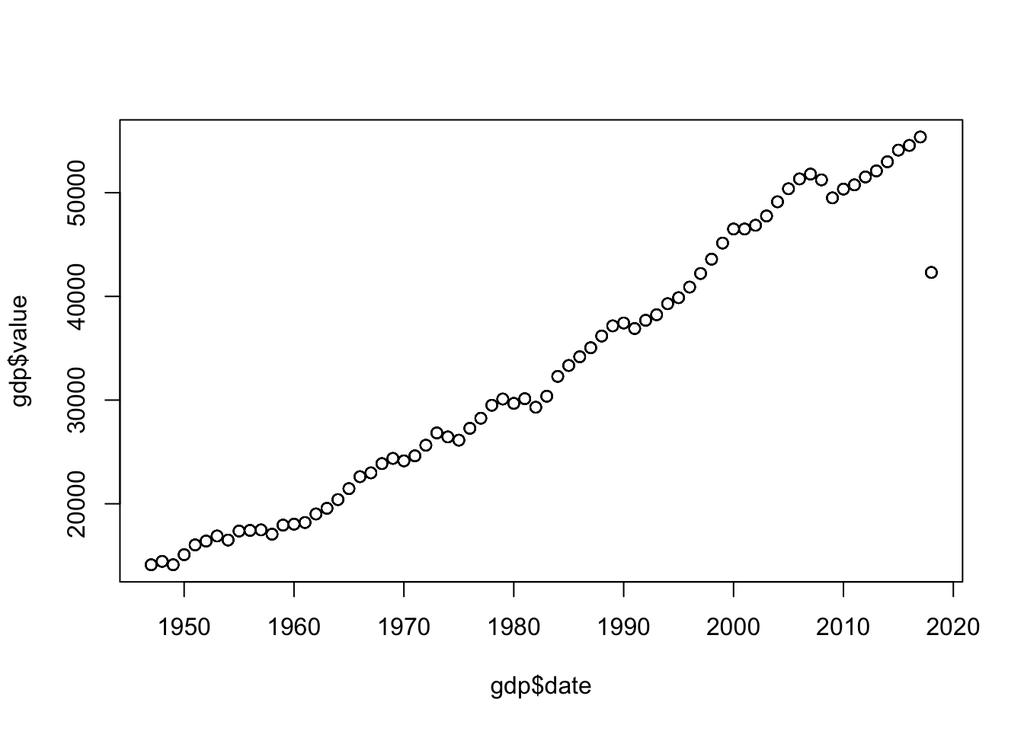

```r
plot(gdp$date,gdp$value)
```

For our analysis we will use the difference in GDP year over year, normalized over the previous value of GDP. This is that is calculated in the datasets Diff column

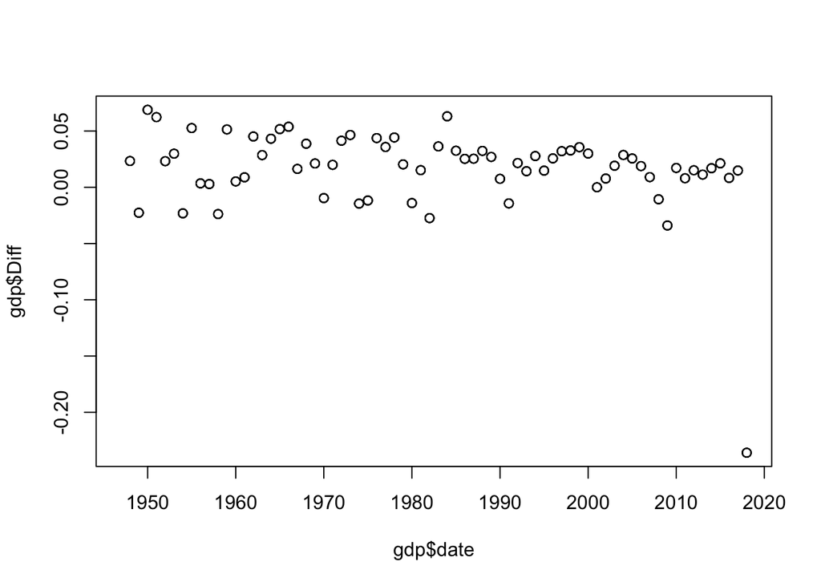

```r
plot(gdp$date,gdp$Diff)
```

```r
gdp_congress<-gdp
gdp_congress$date <- as.numeric(gdp_congress$date)
gdp_congress$Diff <- as.double(gdp_congress$Diff)


gdp_congress <- gdp_congress%>%inner_join(congress)
```

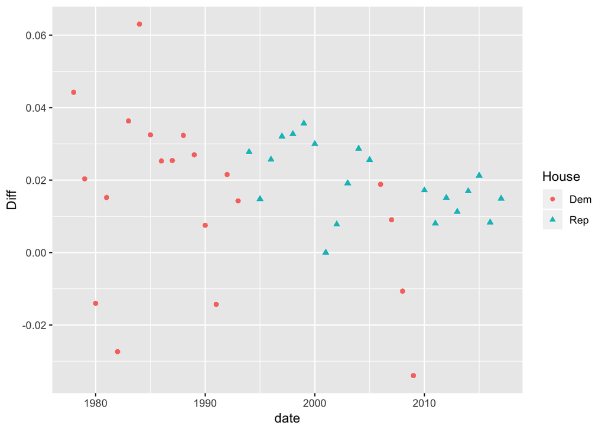

```r
ggplot(gdp_congress, aes(x=date, y=Diff, shape=House, color=House)) +
  geom_point()
```

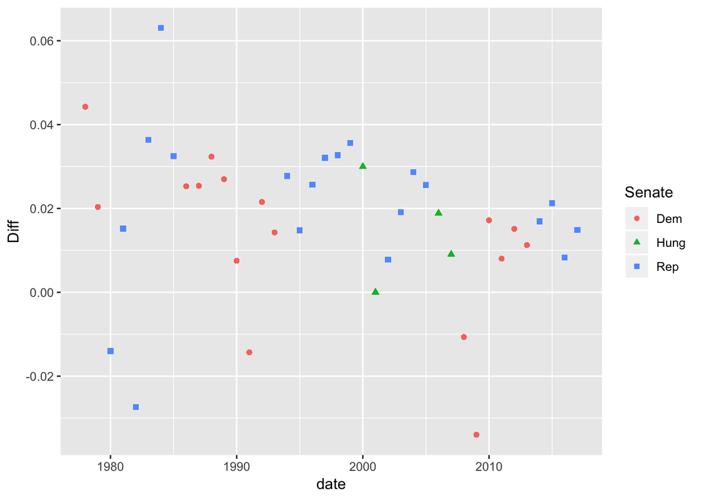

```r
ggplot(gdp_congress, aes(x=date, y=Diff, shape=Senate, color=Senate)) +
  geom_point()
```

**RPCE Data*

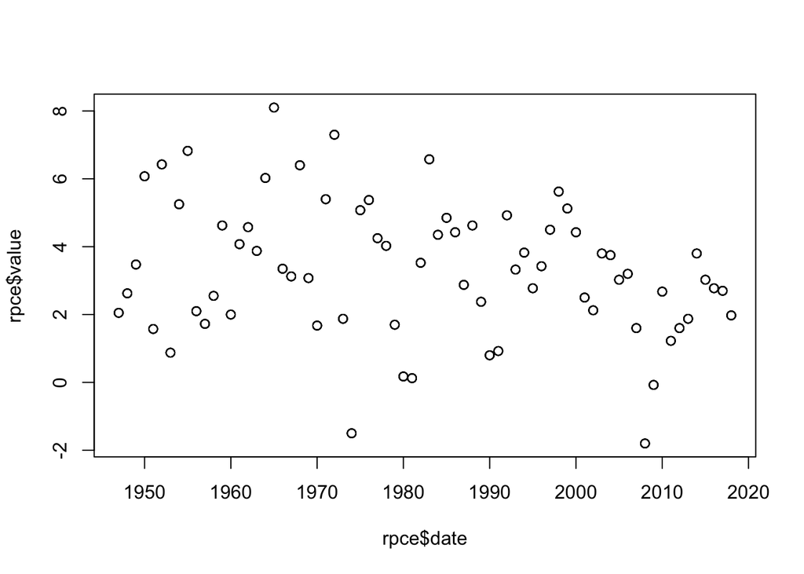

```r
plot(rpce$date,rpce$value)
```

```r
rpce_congress<-rpce
rpce_congress$date <- as.numeric(rpce_congress$date)
rpce_congress$value <- as.double(rpce_congress$value)


rpce_congress <- rpce_congress%>%inner_join(congress)
```

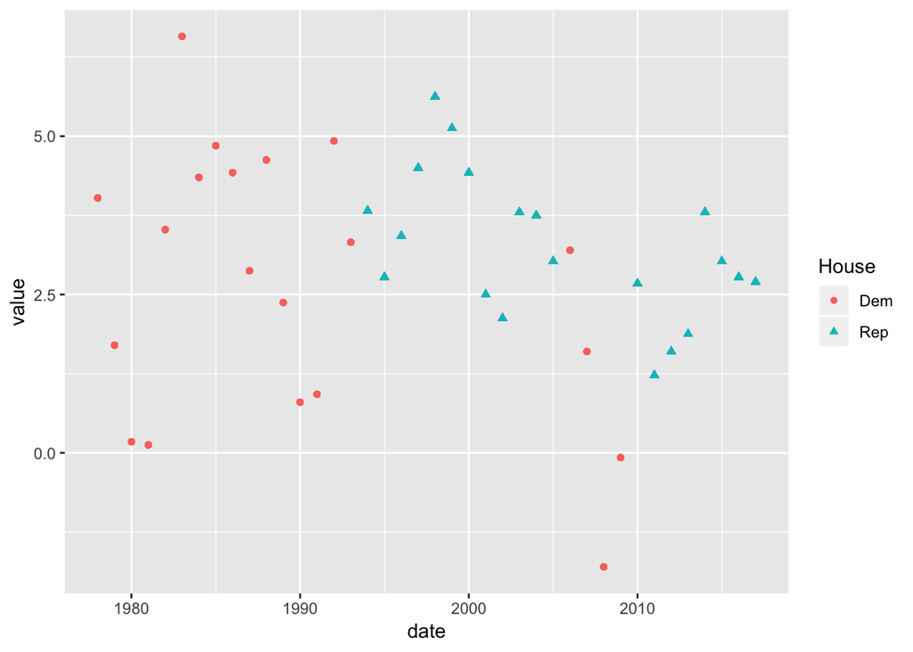

```r
ggplot(rpce_congress, aes(x=date, y=value, shape=House, color=House)) +
  geom_point()
```

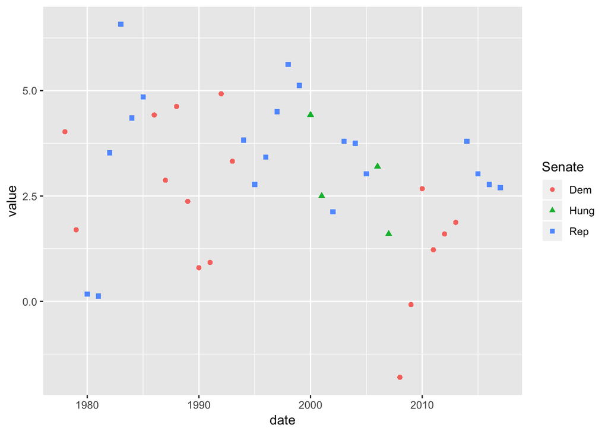

```r
ggplot(rpce_congress, aes(x=date, y=value, shape=Senate, color=Senate)) +
  geom_point()
```

# Model

## Economic Indicator Predictor

### GDP Models

A simple model can determine the expected GDP normilized difference year on year value for a year where the Democratic or Republican party is majority in each chamber.

**House controlled by the Democratic Party**

```r
gdp_congress_house_dem<-subset(gdp_congress,gdp_congress$House=="Dem")
mean(gdp_congress_house_dem$Diff)
```

```
## [1] 0.0146259
```

**House controlled by the Republican Party**

```r
gdp_congress_house_rep<-subset(gdp_congress,gdp_congress$House=="Rep")
mean(gdp_congress_house_rep$Diff)
```

```
## [1] 0.01963483
```

**Senate controlled by the Democratic Party**

```r
gdp_congress_senate_dem<-subset(gdp_congress,gdp_congress$Senate=="Dem")
mean(gdp_congress_senate_dem$Diff)
```

```
## [1] 0.0131594
```

**Senate controlled by the Republican Party**

```r
gdp_congress_senate_rep<-subset(gdp_congress,gdp_congress$Senate=="Rep")
mean(gdp_congress_senate_rep$Diff)
```

```
## [1] 0.02084138
```

**Senate controlled by the Republican Party and House by the Democratic Party**

```r
gdp_congress_senate_rep_house_dem<-subset(gdp_congress,rpce_congress$Senate=="Rep" & gdp_congress$House=="Dem")
mean(gdp_congress_senate_rep_house_dem$Diff)
```

```
## [1] 0.01760847
```

**GDP Diff predicted by number of Democratic Party seats in congress**

To derive this model we build a linear regression of GDP Diff agaisnt the number of Democratic seats in each chamber.

**House**

```r
congress_gdp<-inner_join(congress,gdp)
```

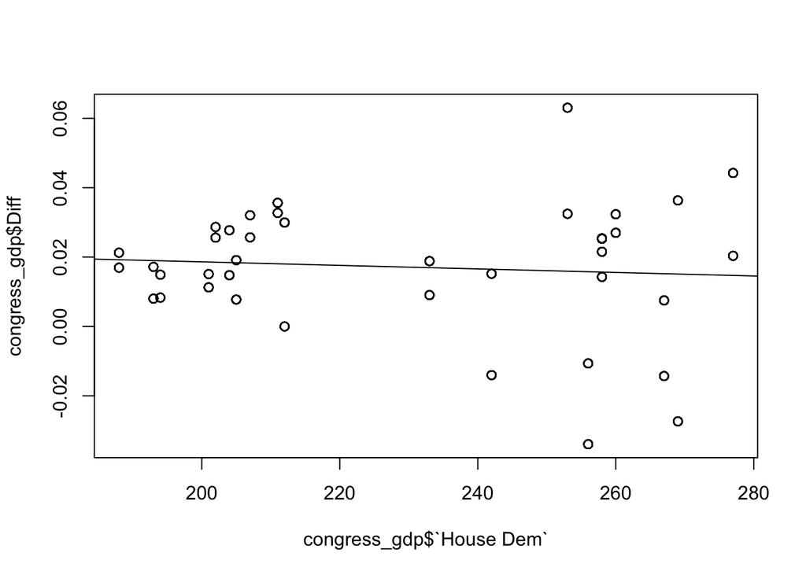

```r
congress_gdp$`House Dem`<-as.numeric(congress_gdp$`House Dem`)
gdp_house_model<-lm(Diff ~ `House Dem`,data = congress_gdp)
plot(congress_gdp$`House Dem`,congress_gdp$Diff)
abline(gdp_house_model)
```

```r
summary(gdp_house_model)
```

```
##
## Call:
## lm(formula = Diff ~ `House Dem`, data = congress_gdp)
##
## Residuals:
##       Min        1Q    Median        3Q       Max
## -0.049738 -0.007757  0.001315  0.010454  0.047120
##
## Coefficients:
##               Estimate Std. Error t value Pr(>|t|)
## (Intercept)  2.885e-02  3.766e-03   7.663 3.33e-14 ***
## `House Dem` -5.109e-05  1.627e-05  -3.139  0.00173 **
## ---
## Signif. codes:  0 '***' 0.001 '**' 0.01 '*' 0.05 '.' 0.1 ' ' 1
##
## Residual standard error: 0.01826 on 1438 degrees of freedom
## Multiple R-squared:  0.006806,   Adjusted R-squared:  0.006116
## F-statistic: 9.855 on 1 and 1438 DF,  p-value: 0.001729
```

**Senate**

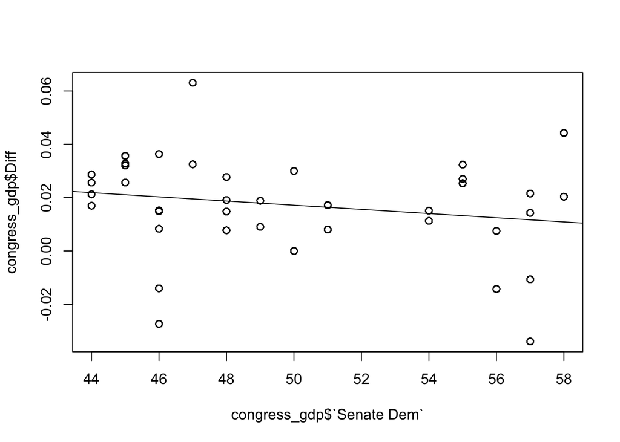

```r
congress_gdp$`Senate Dem`<-as.numeric(congress_gdp$`Senate Dem`)
gdp_senate_model<-lm(Diff ~ `Senate Dem`,data = congress_gdp)
plot(congress_gdp$`Senate Dem`,congress_gdp$Diff)
abline(gdp_senate_model)
```

```r
summary(gdp_senate_model)
```

```
##
## Call:
## lm(formula = Diff ~ `Senate Dem`, data = congress_gdp)
##
## Residuals:
##       Min        1Q    Median        3Q       Max
## -0.047680 -0.006144  0.000974  0.011724  0.043526
##
## Coefficients:
##                Estimate Std. Error t value Pr(>|t|)
## (Intercept)   5.641e-02  4.994e-03  11.296  < 2e-16 ***
## `Senate Dem` -7.849e-04  9.933e-05  -7.901 5.44e-15 ***
## ---
## Signif. codes:  0 '***' 0.001 '**' 0.01 '*' 0.05 '.' 0.1 ' ' 1
##
## Residual standard error: 0.01794 on 1438 degrees of freedom
## Multiple R-squared:  0.04161,    Adjusted R-squared:  0.04094
## F-statistic: 62.43 on 1 and 1438 DF,  p-value: 5.439e-15
```

### RPCE Models

**RPCE prediced by majority Party**

A simple model can determine the expected RPCE value for a year where the Democratic or Republican party is majority in each chamber.

**House controlled by the Democratic Party**

```r
rpce_congress_house_dem<-subset(rpce_congress,rpce_congress$House=="Dem")
mean(rpce_congress_house_dem$value)
```

```
## [1] 2.62625
```

**House controlled by the Republican Party**

```r
rpce_congress_house_rep<-subset(rpce_congress,rpce_congress$House=="Rep")
mean(rpce_congress_house_rep$value)
```

```
## [1] 3.22875
```

**Senate controlled by the Democratic Party**

```r
rpce_congress_senate_dem<-subset(rpce_congress,rpce_congress$Senate=="Dem")
mean(rpce_congress_senate_dem$value)
```

```
## [1] 2.21875
```

**Senate controlled by the Republican Party**

```r
rpce_congress_senate_rep<-subset(rpce_congress,rpce_congress$Senate=="Rep")
mean(rpce_congress_senate_rep$value)
```

```
## [1] 3.49375
```

**Senate controlled by the Republican Party and House by the Democratic Party**

```r
rpce_congress_senate_rep_house_dem<-subset(rpce_congress,rpce_congress$Senate=="Rep" & rpce_congress$House=="Dem")
mean(rpce_congress_senate_rep_house_dem$value)
```

```
## [1] 3.266667
```

**RPCE preditced by number of Democratic Party seats in congress**

To derive this model we build a linear regression of RPCE agaisnt the number of Democratic seats in each chamber.

**House**

```r
congress_rpce<-inner_join(congress,rpce)
```

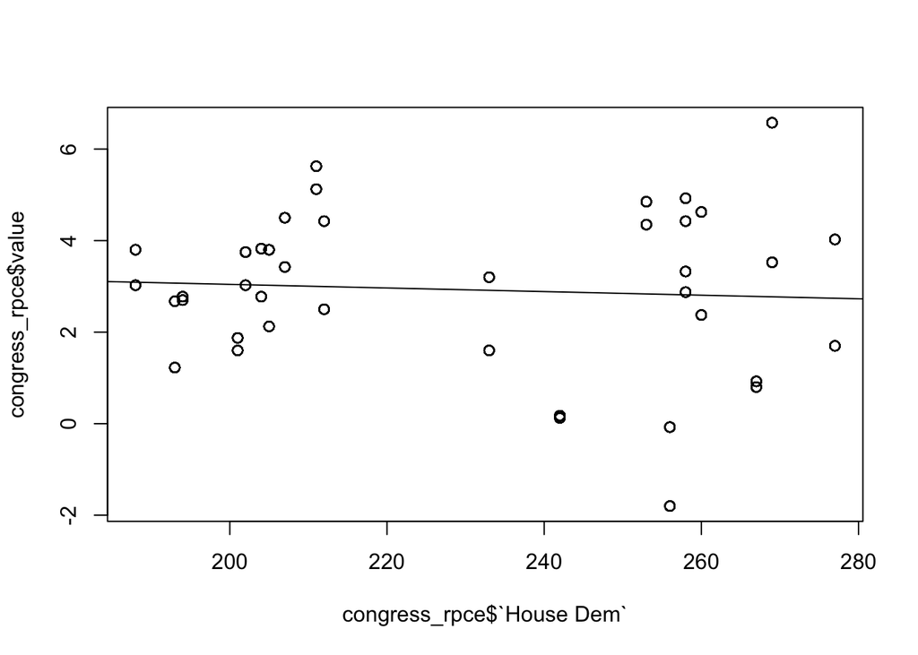

```r
congress_rpce$`House Dem`<-as.numeric(congress_rpce$`House Dem`)
rpce_house_model<-lm(value ~ `House Dem`,data = congress_rpce)
plot(congress_rpce$`House Dem`,congress_rpce$value)
abline(rpce_house_model)
```

```r
summary(rpce_house_model)
```

```
##
## Call:
## lm(formula = value ~ `House Dem`, data = congress_rpce)
##
## Residuals:
##     Min      1Q  Median      3Q     Max
## -4.6231 -1.0715  0.0245  1.3206  3.8031
##
## Coefficients:
##              Estimate Std. Error t value Pr(>|t|)
## (Intercept)  3.831807   0.350110  10.945   <2e-16 ***
## `House Dem` -0.003940   0.001513  -2.604   0.0093 **
## ---
## Signif. codes:  0 '***' 0.001 '**' 0.01 '*' 0.05 '.' 0.1 ' ' 1
##
## Residual standard error: 1.698 on 1438 degrees of freedom
## Multiple R-squared:  0.004694,   Adjusted R-squared:  0.004002
## F-statistic: 6.782 on 1 and 1438 DF,  p-value: 0.009302
```

**Senate**

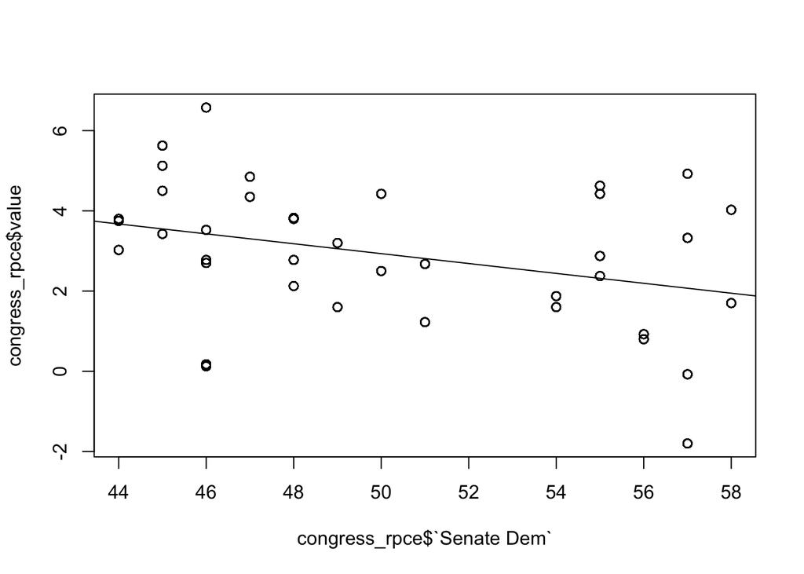

```r
congress_rpce$`Senate Dem`<-as.numeric(congress_rpce$`Senate Dem`)
rpce_senate_model<-lm(value ~ `Senate Dem`,data = congress_rpce)
plot(congress_rpce$`Senate Dem`,congress_rpce$value)
abline(rpce_senate_model)
```

```r
summary(rpce_senate_model)
```

```
##
## Call:
## lm(formula = value ~ `Senate Dem`, data = congress_rpce)
##
## Residuals:
##     Min      1Q  Median      3Q     Max
## -3.8705 -0.7553 -0.0337  1.0984  3.1481
##
## Coefficients:
##               Estimate Std. Error t value Pr(>|t|)
## (Intercept)   9.099081   0.444689   20.46   <2e-16 ***
## `Senate Dem` -0.123308   0.008845  -13.94   <2e-16 ***
## ---
## Signif. codes:  0 '***' 0.001 '**' 0.01 '*' 0.05 '.' 0.1 ' ' 1
##
## Residual standard error: 1.597 on 1438 degrees of freedom
## Multiple R-squared:  0.1191, Adjusted R-squared:  0.1184
## F-statistic: 194.4 on 1 and 1438 DF,  p-value: < 2.2e-16
```

## Modeling Using Python

We experiment with using Python libraries within R. To do this we use the reticulate library. The library was first installed using the command:

install.packages(“reticulate”)

The library was then loaded and the environment on top of which it runs explored. An install of Python was already available in the system, as wells as some Anaconda or conda environments.

```r
library(reticulate)
py_discover_config()
```

```
## python:         /Users/peterkowalchuk/anaconda2/envs/r-reticulate/bin/python
## libpython:      /Users/peterkowalchuk/anaconda2/envs/r-reticulate/lib/libpython3.7m.dylib
## pythonhome:     /Users/peterkowalchuk/anaconda2/envs/r-reticulate:/Users/peterkowalchuk/anaconda2/envs/r-reticulate
## version:        3.7.1 | packaged by conda-forge | (default, Nov 13 2018, 09:50:42)  [Clang 9.0.0 (clang-900.0.37)]
## numpy:          /Users/peterkowalchuk/anaconda2/envs/r-reticulate/lib/python3.7/site-packages/numpy
## numpy_version:  1.15.4
##
## python versions found:
##  /Users/peterkowalchuk/anaconda2/envs/r-reticulate/bin/python
##  /usr/bin/python
##  /usr/local/bin/python
##  /usr/local/bin/python3
##  /Users/peterkowalchuk/anaconda2/envs/python3/bin/python
##  /Users/peterkowalchuk/anaconda2/envs/R/bin/python
##  /Users/peterkowalchuk/anaconda2/bin/python
```

The Python library of interest is Scikit-Learn. This library has a regression model which will be used to recreate what was done in R in the previous section to prove Python libraries can be used in RStudio. This library is installed on the environment being used by reticulate using these commands:

conda_install(“r-reticulate”, “scikit-learn”)

Other libraries were also installed:

conda_install(“r-reticulate”, “numpy”) conda_install(“r-reticulate”, “pandas”)

We then load the libraries

```python
import numpy as np
from sklearn import datasets, linear_model
from sklearn.metrics import mean_squared_error, r2_score
```

As a simple experiment we will use the linear regression functionality in Scikit-Learn to build a model to try to predict the rpce from the number of Democratic seta in the House.

First we look at how we move data from R to Python. We first move the data we will use in the regression to specific variables, and then see those variables in Python using the suffix r.

```r
#R chunk
rpce_house_model<-lm(value ~ `House Dem`,data = congress_rpce)
y<-congress_rpce$value
X<-congress_rpce$'House Dem'
```

We can now see the R data in a Python chunk

```python
#Python chunk
X=np.array(r.X)
X=np.array(X)[np.newaxis]
X=X.T
y=np.array(r.y)
y=np.array(y)[np.newaxis]
y=y.T
```

We can now use this data in scikit-learn and build a linear regression model

```python
#Python chunk
regr = linear_model.LinearRegression()
regr.fit(X,y)
y_p = regr.predict(X)
coef=regr.coef_
inter=regr.intercept_
error=mean_squared_error(y, y_p)
print('Coefficients: \n', coef)
```

```
## Coefficients:
##  [[-0.00394033]]
```

```python
print('Intercept: \n', inter)
```

```
## Intercept:
##  [3.83180664]
```

```python
print("Mean squared error: %.2f"% error)
```

```
## Mean squared error: 2.88
```

Results from our regression are also available in R

```r
#R Chunk
py$coef
```

```
##              [,1]
## [1,] -0.003940334
```

```r
py$inter
```

```
## [1] 3.831807
```

```r
py$error
```

```
## [1] 2.878636
```

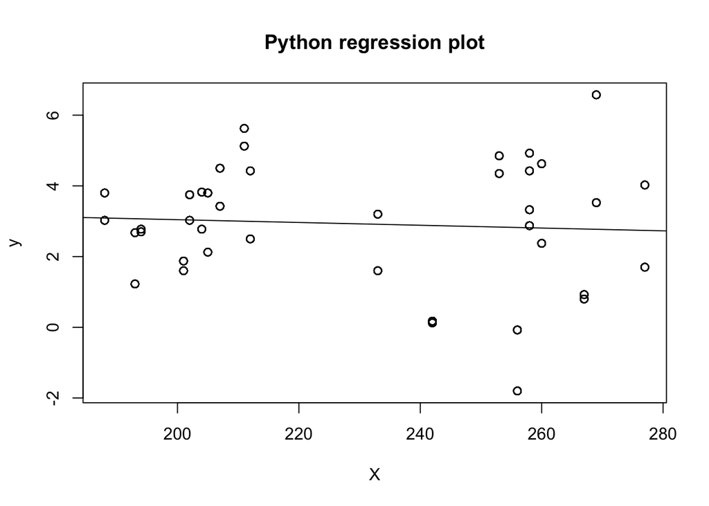

```r
plot(X,y)
abline(py$inter,py$coef)
title("Python regression plot")
```

## Economy Health Classifier

For our Economy Health Classifier we start by procuring a monthly economy indicator from the FRED site.

```r
api.key = "4844eb6986119824760163e60bddd945"
fred<-FredR(api.key)

gdp.series <- fred$series.search("GDP")
#gdp.series
```

We select the current indicator: All Employees: Total Nonfarm Payrolls. After importing it and visualizing it we find it constantly increases with time. This is expected as the number of people employed should increase together with the active population of the nation.

```r
pay <- fred$series.observations(series_id = 'PAYEMS')
head(pay,n=100) %>% kable() %>% kable_styling() %>% scroll_box(height = "400px")
```

| realtime_start | realtime_end | date | value |
| --- | --- | --- | --- |
| 2018-12-09 | 2018-12-09 | 1939-01-01 | 29923 |
| 2018-12-09 | 2018-12-09 | 1939-02-01 | 30101 |
| 2018-12-09 | 2018-12-09 | 1939-03-01 | 30280 |
| 2018-12-09 | 2018-12-09 | 1939-04-01 | 30094 |
| 2018-12-09 | 2018-12-09 | 1939-05-01 | 30300 |
| 2018-12-09 | 2018-12-09 | 1939-06-01 | 30502 |
| 2018-12-09 | 2018-12-09 | 1939-07-01 | 30419 |
| 2018-12-09 | 2018-12-09 | 1939-08-01 | 30663 |
| 2018-12-09 | 2018-12-09 | 1939-09-01 | 31032 |
| 2018-12-09 | 2018-12-09 | 1939-10-01 | 31408 |
| 2018-12-09 | 2018-12-09 | 1939-11-01 | 31469 |
| 2018-12-09 | 2018-12-09 | 1939-12-01 | 31539 |
| 2018-12-09 | 2018-12-09 | 1940-01-01 | 31603 |
| 2018-12-09 | 2018-12-09 | 1940-02-01 | 31715 |
| 2018-12-09 | 2018-12-09 | 1940-03-01 | 31826 |
| 2018-12-09 | 2018-12-09 | 1940-04-01 | 31700 |
| 2018-12-09 | 2018-12-09 | 1940-05-01 | 31880 |
| 2018-12-09 | 2018-12-09 | 1940-06-01 | 31978 |
| 2018-12-09 | 2018-12-09 | 1940-07-01 | 31942 |
| 2018-12-09 | 2018-12-09 | 1940-08-01 | 32352 |
| 2018-12-09 | 2018-12-09 | 1940-09-01 | 32810 |
| 2018-12-09 | 2018-12-09 | 1940-10-01 | 33265 |
| 2018-12-09 | 2018-12-09 | 1940-11-01 | 33668 |
| 2018-12-09 | 2018-12-09 | 1940-12-01 | 34172 |
| 2018-12-09 | 2018-12-09 | 1941-01-01 | 34480 |
| 2018-12-09 | 2018-12-09 | 1941-02-01 | 34844 |
| 2018-12-09 | 2018-12-09 | 1941-03-01 | 35094 |
| 2018-12-09 | 2018-12-09 | 1941-04-01 | 35469 |
| 2018-12-09 | 2018-12-09 | 1941-05-01 | 36182 |
| 2018-12-09 | 2018-12-09 | 1941-06-01 | 36651 |

[output cut: 70 more lines]

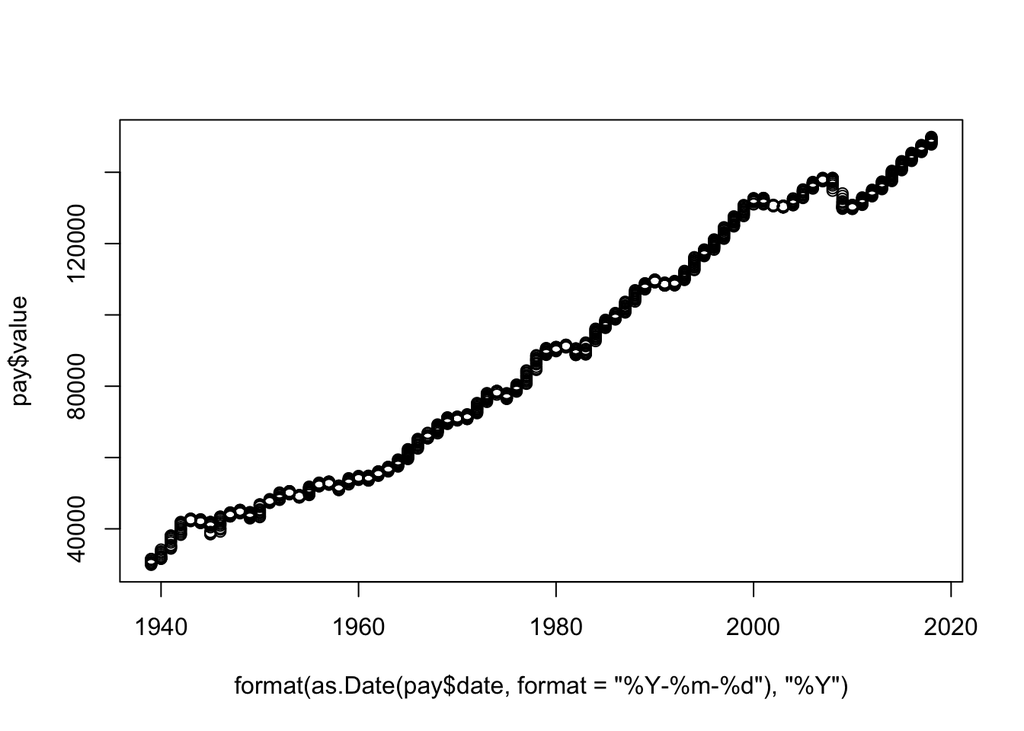

```r
plot(format(as.Date(pay$date,format="%Y-%m-%d"),"%Y"),pay$value)
```

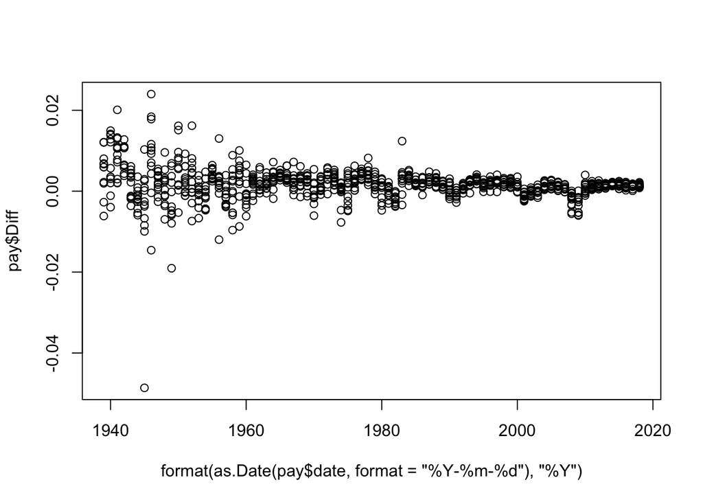

```r
pay$value<-as.numeric(pay$value)
pay <- pay %>% mutate(Diff = (value - lag(value))/lag(value))
plot(format(as.Date(pay$date,format="%Y-%m-%d"),"%Y"),pay$Diff)
```

Visual inspection of the data reveals how payrolls made wide positive and negative swings during the 40’s and 50’s. After 1960 the data shows much clearer with possible patterns emerging. Our analysis will concentrate on data starting from 1978, which is the period for which we have congress party composition data.

To build our classifier we need to establish thresholds for good, medium and poor economy. The idea is that high employment growth represents a good economy, and low employment growth is a bad economy. We look at a summary of our data to determine what would be good thresholds to use.

```r
pay<-na.omit(pay)
summary(pay$Diff)
```

```
##       Min.    1st Qu.     Median       Mean    3rd Qu.       Max.
## -0.0486075  0.0002276  0.0017003  0.0016911  0.0030992  0.0239994
```

We classify our data as: - Poor economy: payroll growth below 1st quartile - Medium economy: payroll growth between 1st and 3rd quartile - Good economy: payroll growth above 3rd quartile

```r
poor<-summary(pay$Diff)[2]
good<-summary(pay$Diff)[5]
pay$Health <- ifelse(pay$Diff < poor, "Bad", "Medium")
pay$Health <- ifelse(pay$Diff > good, "Good", pay$Health)
```

Now that we have our output classification ready, our classifier will use as input features the number of congressional seats in Congress per party for both chambers. We build a table with our classification and the six input features (Democratic, Republican and Other number of seats for both the House and Senate).

Do be able to join the payroll with the congressional dataset, we need to first fill in monthly rows in the congressional table.

```r
monthy_congress<-congress %>% slice(rep(1:n(), each = 12))
colnames(monthy_congress)[1]<-"Year"
pay$Year<-substring(pay$date,1,4)
pay$Year<-as.numeric(pay$Year)
health_congress<-inner_join(pay,monthy_congress) %>% select(6:13) %>% subset(select=-Year)
```

The resulting dataset from these transformations has the classifier’s 6 input features, and the three level economy healt output.

With our data ready we can now select a scikit-learn classifier to use. We will use the MLPClassifier in Scikit-Learn, which implements a neural network classifier. We build the required input for the trassifier by transforming the data in our table. The classifier requires a X matrix with samplesxfeatures, and a y vector with samples.

```r
library(reticulate)

X<-subset(health_congress,select = -Health)
X<-data.matrix(X)

y<-health_congress$Health
y <- ifelse(y == "Bad", 0, y)
y <- ifelse(y == "Medium", 1, y)
y <- ifelse(y == "Good", 2, y)
```

```python
import numpy as np
from sklearn.neural_network import MLPClassifier
from sklearn.model_selection import train_test_split
from sklearn.metrics import confusion_matrix
X=np.array(r.X)
X=X.astype(np.float)
y=list(map(int,r.y))
X_train, X_test, y_train, y_test = train_test_split(X, y, test_size=0.3)
clf = MLPClassifier(solver='lbfgs', alpha=1e-5,hidden_layer_sizes=(415, 218), random_state=1)
clf.fit(X_train, y_train)
y_pred = clf.predict(X_test)
cnf_matrix = confusion_matrix(y_test, y_pred)
print(cnf_matrix)
```

```
## [[   0 2207  290]
##  [   0 6760   81]
##  [   0  893  137]]
```

```python
res=clf.predict([[47, 51, 2, 197, 236, 0], [45, 53, 2, 235, 199, 0]])
```

```r
py$cnf_matrix
```

```
##      [,1] [,2] [,3]
## [1,]    0 2207  290
## [2,]    0 6760   81
## [3,]    0  893  137
```

```r
cnf_matrix<-as.data.frame(as.table(py$cnf_matrix))
colnames(cnf_matrix)<-c("Real","Prediction","Count")
cnf_matrix
```

```
##   Real Prediction Count
## 1    A          A     0
## 2    B          A     0
## 3    C          A     0
## 4    A          B  2207
## 5    B          B  6760
## 6    C          B   893
## 7    A          C   290
## 8    B          C    81
## 9    C          C   137
```

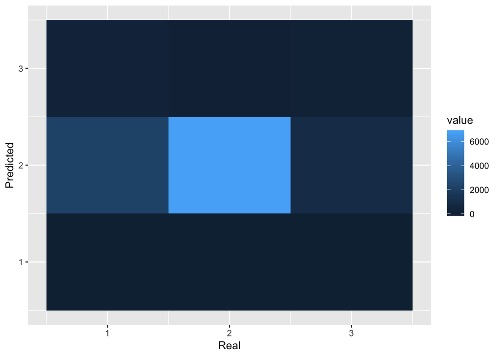

```r
library(reshape2)
melted_matrix <- melt(py$cnf_matrix)
library(ggplot2)
ggplot(data = melted_matrix, aes(x=Var1, y=Var2, fill=value)) +
  geom_tile() + labs(x = "Real", y = "Predicted")
```

```r
res<-py$res
res <- ifelse(res == 0,"Bad", res)
res <- ifelse(res == 1,"Medium", res)
res <- ifelse(res == 2,"Good", res)
res
```

```
## [1] "Medium" "Medium"
```

# Communicate

## Data Science

Based on the analysis here presented, this is what we can expect as an economic outlook for next year.

**GDP**

Since the House will be lead by the Democratic party we expect GDP normilized difference to be around 0.0146259. But since the Senate will be leading the Senate, GDP normilized difference should come at 0.02084138. Since we are looking at a divided congress, expected GDP normilized difference is that for a Senate controlled by Republicans and House by Democrats, which is **0.01760847**

**RPCE**

Since the House will be lead by the Democratic party we expect RPCE to be around 2.62625. But since the Senate will be leading the Senate, RPCE should come at 3.49375. Since we are looking at a divided congress, expected RPCE is that for a Senate controlled by Republicans and House by Democrats, which is **3.266667**

**Classifier**

Using a neural network classifier we predict that the change in composition of the US Congress from 2018 to 2019 does not indicate a change in the state of the country’s economy. But the classifier derived from the analysis shows lack of performance against a test set. This classifier should be revised and upgraded.

## Data Engineering

**Modeling in Python**

Using the R Reticulate library, we are able to use Python packages in RStudio to produce models using data available in R.

A Python classifier taken from the popular library Scikit-Learn can be called from within R, trained, and results sent back to R for presentation or further analysis.

At least one Python library, matplotlib, presented issues when running from R using the Reticulate library.